# Risk Factor Analysis

## Outcome Variable

**Outcome Variable:** stunted

## Predictor Variables

**Intervention Variable:** predfeed6

**Adjustment Set:**

unadjusted

## Stratifying Variables

The analysis was stratified on these variable(s):

- agecat
- studyid
- country

## Data Summary

| agecat | studyid | country | predfeed6 | stunted | n_cell | n |
| --- | --- | --- | --- | --- | --- | --- |
| Birth | EE | PAKISTAN | 1 | 0 | 22 | 42 |
| Birth | EE | PAKISTAN | 1 | 1 | 16 | 42 |
| Birth | EE | PAKISTAN | 0 | 0 | 3 | 42 |
| Birth | EE | PAKISTAN | 0 | 1 | 1 | 42 |
| Birth | GMS-Nepal | NEPAL | 1 | 0 | 351 | 563 |
| Birth | GMS-Nepal | NEPAL | 1 | 1 | 68 | 563 |
| Birth | GMS-Nepal | NEPAL | 0 | 0 | 118 | 563 |
| Birth | GMS-Nepal | NEPAL | 0 | 1 | 26 | 563 |
| Birth | MAL-ED | BANGLADESH | 1 | 0 | 60 | 205 |
| Birth | MAL-ED | BANGLADESH | 1 | 1 | 12 | 205 |
| Birth | MAL-ED | BANGLADESH | 0 | 0 | 109 | 205 |
| Birth | MAL-ED | BANGLADESH | 0 | 1 | 24 | 205 |
| Birth | MAL-ED | BRAZIL | 1 | 0 | 4 | 60 |
| Birth | MAL-ED | BRAZIL | 1 | 1 | 2 | 60 |
| Birth | MAL-ED | BRAZIL | 0 | 0 | 47 | 60 |
| Birth | MAL-ED | BRAZIL | 0 | 1 | 7 | 60 |
| Birth | MAL-ED | INDIA | 1 | 0 | 2 | 39 |
| Birth | MAL-ED | INDIA | 1 | 1 | 2 | 39 |
| Birth | MAL-ED | INDIA | 0 | 0 | 29 | 39 |
| Birth | MAL-ED | INDIA | 0 | 1 | 6 | 39 |
| Birth | MAL-ED | NEPAL | 1 | 0 | 3 | 24 |
| Birth | MAL-ED | NEPAL | 1 | 1 | 0 | 24 |
| Birth | MAL-ED | NEPAL | 0 | 0 | 20 | 24 |
| Birth | MAL-ED | NEPAL | 0 | 1 | 1 | 24 |
| Birth | MAL-ED | PERU | 1 | 0 | 66 | 213 |
| Birth | MAL-ED | PERU | 1 | 1 | 7 | 213 |
| Birth | MAL-ED | PERU | 0 | 0 | 121 | 213 |
| Birth | MAL-ED | PERU | 0 | 1 | 19 | 213 |
| Birth | MAL-ED | SOUTH AFRICA | 1 | 0 | 1 | 91 |
| Birth | MAL-ED | SOUTH AFRICA | 1 | 1 | 0 | 91 |

[output cut: 90 more lines]

The following strata were considered:

- agecat: 24 months, studyid: EE, country: PAKISTAN
- agecat: 24 months, studyid: GMS-Nepal, country: NEPAL
- agecat: 24 months, studyid: LCNI-5, country: MALAWI
- agecat: 24 months, studyid: MAL-ED, country: BANGLADESH
- agecat: 24 months, studyid: MAL-ED, country: BRAZIL
- agecat: 24 months, studyid: MAL-ED, country: INDIA
- agecat: 24 months, studyid: MAL-ED, country: NEPAL
- agecat: 24 months, studyid: MAL-ED, country: PERU
- agecat: 24 months, studyid: MAL-ED, country: SOUTH AFRICA
- agecat: 24 months, studyid: MAL-ED, country: TANZANIA, UNITED REPUBLIC OF
- agecat: 6 months, studyid: EE, country: PAKISTAN
- agecat: 6 months, studyid: GMS-Nepal, country: NEPAL
- agecat: 6 months, studyid: LCNI-5, country: MALAWI
- agecat: 6 months, studyid: MAL-ED, country: BANGLADESH
- agecat: 6 months, studyid: MAL-ED, country: BRAZIL
- agecat: 6 months, studyid: MAL-ED, country: INDIA
- agecat: 6 months, studyid: MAL-ED, country: NEPAL
- agecat: 6 months, studyid: MAL-ED, country: PERU
- agecat: 6 months, studyid: MAL-ED, country: SOUTH AFRICA
- agecat: 6 months, studyid: MAL-ED, country: TANZANIA, UNITED REPUBLIC OF
- agecat: 6 months, studyid: SAS-FoodSuppl, country: INDIA
- agecat: Birth, studyid: EE, country: PAKISTAN
- agecat: Birth, studyid: GMS-Nepal, country: NEPAL
- agecat: Birth, studyid: MAL-ED, country: BANGLADESH
- agecat: Birth, studyid: MAL-ED, country: BRAZIL
- agecat: Birth, studyid: MAL-ED, country: INDIA
- agecat: Birth, studyid: MAL-ED, country: NEPAL
- agecat: Birth, studyid: MAL-ED, country: PERU
- agecat: Birth, studyid: MAL-ED, country: SOUTH AFRICA
- agecat: Birth, studyid: MAL-ED, country: TANZANIA, UNITED REPUBLIC OF

### Dropped Strata

Some strata were dropped due to rare outcomes:

- agecat: Birth, studyid: EE, country: PAKISTAN
- agecat: Birth, studyid: MAL-ED, country: BRAZIL
- agecat: Birth, studyid: MAL-ED, country: INDIA
- agecat: Birth, studyid: MAL-ED, country: NEPAL
- agecat: Birth, studyid: MAL-ED, country: SOUTH AFRICA
- agecat: Birth, studyid: MAL-ED, country: TANZANIA, UNITED REPUBLIC OF
- agecat: 6 months, studyid: EE, country: PAKISTAN
- agecat: 6 months, studyid: MAL-ED, country: BRAZIL
- agecat: 6 months, studyid: MAL-ED, country: INDIA
- agecat: 6 months, studyid: MAL-ED, country: NEPAL
- agecat: 6 months, studyid: MAL-ED, country: SOUTH AFRICA
- agecat: 6 months, studyid: MAL-ED, country: TANZANIA, UNITED REPUBLIC OF
- agecat: 6 months, studyid: SAS-FoodSuppl, country: INDIA
- agecat: 24 months, studyid: EE, country: PAKISTAN
- agecat: 24 months, studyid: MAL-ED, country: BRAZIL
- agecat: 24 months, studyid: MAL-ED, country: INDIA
- agecat: 24 months, studyid: MAL-ED, country: NEPAL
- agecat: 24 months, studyid: MAL-ED, country: SOUTH AFRICA
- agecat: 24 months, studyid: MAL-ED, country: TANZANIA, UNITED REPUBLIC OF

## Methods Detail

We’re interested in the causal parameters $E[Y_a]$ for all values of $a \in \mathcal{A}$. These parameters represent the mean outcome if, possibly contrary to fact, we intervened to set all units to have $A=a$. Under the randomization and positivity assumptions, these are identified by the statistical parameters $\psi_a=E_W[E_{Y|A,W}(Y|A=a,W)]$. In addition, we’re interested in the mean of $Y$, $E[Y]$ under no intervention (the observed mean). We will estimate these parameters by using SuperLearner to fit the relevant likelihood factors – $E_{Y|A,W}(Y|A=a,W)$ and $p(A=a|W)$, and then updating our likelihood fit using a joint TMLE.

For unadjusted analyses ($W=\{\}$), initial likelihoods were estimated using Lrnr_glm to estimate the simple $E(Y|A)$ and Lrnr_mean to estimate $p(A)$. For adjusted analyses, a small library containing Lrnr_glmnet, Lrnr_xgboost, and Lrnr_mean was used.

Having estimated these parameters, we will then use the delta method to estimate relative risks and attributable risks relative to a prespecified baseline level of $A$.

# Results Detail

## Results Plots

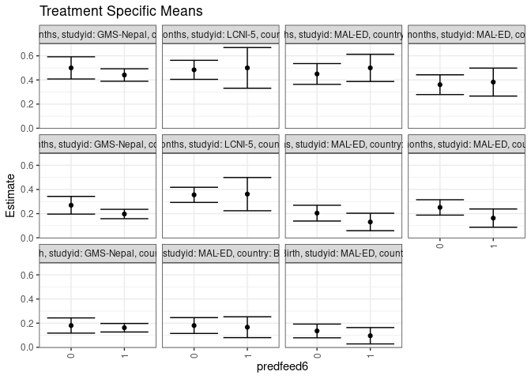

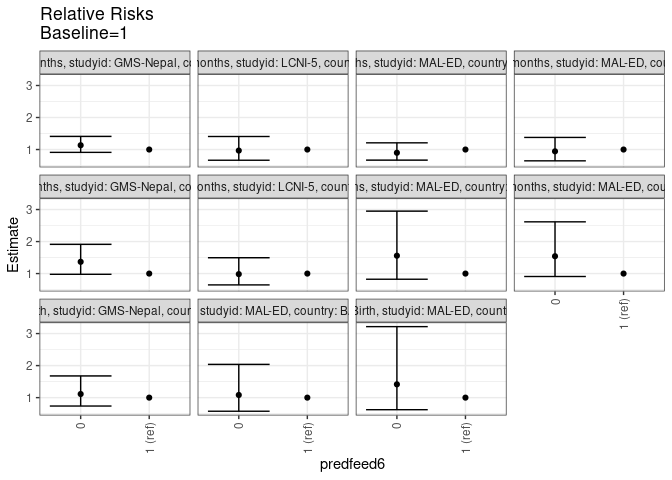

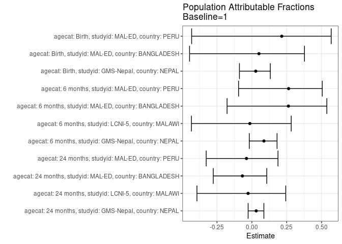

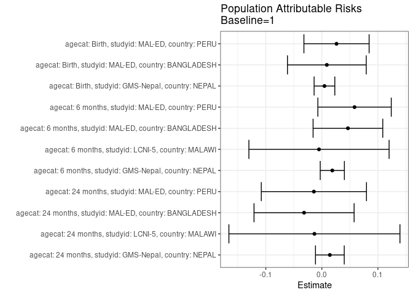

## Results Table

### Parameter: TSM

| agecat | studyid | country | intervention_level | baseline_level | estimate | ci_lower | ci_upper |
| --- | --- | --- | --- | --- | --- | --- | --- |
| Birth | GMS-Nepal | NEPAL | 1 | NA | 0.1622912 | 0.1269549 | 0.1976275 |
| Birth | GMS-Nepal | NEPAL | 0 | NA | 0.1805556 | 0.1176748 | 0.2434364 |
| Birth | MAL-ED | BANGLADESH | 1 | NA | 0.1666667 | 0.0803733 | 0.2529600 |
| Birth | MAL-ED | BANGLADESH | 0 | NA | 0.1804511 | 0.1149345 | 0.2459677 |
| Birth | MAL-ED | PERU | 1 | NA | 0.0958904 | 0.0281876 | 0.1635932 |
| Birth | MAL-ED | PERU | 0 | NA | 0.1357143 | 0.0788490 | 0.1925796 |
| 6 months | GMS-Nepal | NEPAL | 1 | NA | 0.1970443 | 0.1583177 | 0.2357710 |
| 6 months | GMS-Nepal | NEPAL | 0 | NA | 0.2695035 | 0.1961996 | 0.3428075 |
| 6 months | LCNI-5 | MALAWI | 1 | NA | 0.3617021 | 0.2240807 | 0.4993236 |
| 6 months | LCNI-5 | MALAWI | 0 | NA | 0.3555556 | 0.2928937 | 0.4182174 |
| 6 months | MAL-ED | BANGLADESH | 1 | NA | 0.1309524 | 0.0586539 | 0.2032508 |
| 6 months | MAL-ED | BANGLADESH | 0 | NA | 0.2040816 | 0.1387885 | 0.2693748 |
| 6 months | MAL-ED | PERU | 1 | NA | 0.1630435 | 0.0874194 | 0.2386676 |
| 6 months | MAL-ED | PERU | 0 | NA | 0.2513966 | 0.1877274 | 0.3150659 |
| 24 months | GMS-Nepal | NEPAL | 1 | NA | 0.4410112 | 0.3893801 | 0.4926424 |
| 24 months | GMS-Nepal | NEPAL | 0 | NA | 0.5000000 | 0.4081185 | 0.5918815 |
| 24 months | LCNI-5 | MALAWI | 1 | NA | 0.5000000 | 0.3314881 | 0.6685119 |
| 24 months | LCNI-5 | MALAWI | 0 | NA | 0.4838710 | 0.4049889 | 0.5627530 |
| 24 months | MAL-ED | BANGLADESH | 1 | NA | 0.5000000 | 0.3873132 | 0.6126868 |
| 24 months | MAL-ED | BANGLADESH | 0 | NA | 0.4496124 | 0.3635589 | 0.5356659 |
| 24 months | MAL-ED | PERU | 1 | NA | 0.3823529 | 0.2665608 | 0.4981451 |
| 24 months | MAL-ED | PERU | 0 | NA | 0.3609023 | 0.2790777 | 0.4427268 |

### Parameter: E(Y)

| agecat | studyid | country | intervention_level | baseline_level | estimate | ci_lower | ci_upper |
| --- | --- | --- | --- | --- | --- | --- | --- |
| Birth | GMS-Nepal | NEPAL | NA | NA | 0.1669627 | 0.1361293 | 0.1977961 |
| Birth | MAL-ED | BANGLADESH | NA | NA | 0.1756098 | 0.1233973 | 0.2278222 |
| Birth | MAL-ED | PERU | NA | NA | 0.1220657 | 0.0779993 | 0.1661322 |
| 6 months | GMS-Nepal | NEPAL | NA | NA | 0.2157221 | 0.1812209 | 0.2502233 |
| 6 months | LCNI-5 | MALAWI | NA | NA | 0.3566176 | 0.2995882 | 0.4136471 |
| 6 months | MAL-ED | BANGLADESH | NA | NA | 0.1774892 | 0.1281103 | 0.2268680 |
| 6 months | MAL-ED | PERU | NA | NA | 0.2214022 | 0.1718784 | 0.2709260 |
| 24 months | GMS-Nepal | NEPAL | NA | NA | 0.4553191 | 0.4102488 | 0.5003895 |
| 24 months | LCNI-5 | MALAWI | NA | NA | 0.4867725 | 0.4153250 | 0.5582200 |
| 24 months | MAL-ED | BANGLADESH | NA | NA | 0.4682927 | 0.3998183 | 0.5367670 |
| 24 months | MAL-ED | PERU | NA | NA | 0.3681592 | 0.3013164 | 0.4350020 |

### Parameter: RR

| agecat | studyid | country | intervention_level | baseline_level | estimate | ci_lower | ci_upper |
| --- | --- | --- | --- | --- | --- | --- | --- |
| Birth | GMS-Nepal | NEPAL | 1 | 1 | 1.0000000 | 1.0000000 | 1.000000 |
| Birth | GMS-Nepal | NEPAL | 0 | 1 | 1.1125408 | 0.7378028 | 1.677612 |
| Birth | MAL-ED | BANGLADESH | 1 | 1 | 1.0000000 | 1.0000000 | 1.000000 |
| Birth | MAL-ED | BANGLADESH | 0 | 1 | 1.0827068 | 0.5752737 | 2.037733 |
| Birth | MAL-ED | PERU | 1 | 1 | 1.0000000 | 1.0000000 | 1.000000 |
| Birth | MAL-ED | PERU | 0 | 1 | 1.4153061 | 0.6227136 | 3.216714 |
| 6 months | GMS-Nepal | NEPAL | 1 | 1 | 1.0000000 | 1.0000000 | 1.000000 |
| 6 months | GMS-Nepal | NEPAL | 0 | 1 | 1.3677305 | 0.9778296 | 1.913101 |
| 6 months | LCNI-5 | MALAWI | 1 | 1 | 1.0000000 | 1.0000000 | 1.000000 |
| 6 months | LCNI-5 | MALAWI | 0 | 1 | 0.9830065 | 0.6463228 | 1.495076 |
| 6 months | MAL-ED | BANGLADESH | 1 | 1 | 1.0000000 | 1.0000000 | 1.000000 |
| 6 months | MAL-ED | BANGLADESH | 0 | 1 | 1.5584416 | 0.8233178 | 2.949943 |
| 6 months | MAL-ED | PERU | 1 | 1 | 1.0000000 | 1.0000000 | 1.000000 |
| 6 months | MAL-ED | PERU | 0 | 1 | 1.5418994 | 0.9089616 | 2.615571 |
| 24 months | GMS-Nepal | NEPAL | 1 | 1 | 1.0000000 | 1.0000000 | 1.000000 |
| 24 months | GMS-Nepal | NEPAL | 0 | 1 | 1.1337580 | 0.9117855 | 1.409769 |
| 24 months | LCNI-5 | MALAWI | 1 | 1 | 1.0000000 | 1.0000000 | 1.000000 |
| 24 months | LCNI-5 | MALAWI | 0 | 1 | 0.9677419 | 0.6655301 | 1.407186 |
| 24 months | MAL-ED | BANGLADESH | 1 | 1 | 1.0000000 | 1.0000000 | 1.000000 |
| 24 months | MAL-ED | BANGLADESH | 0 | 1 | 0.8992248 | 0.6690477 | 1.208591 |
| 24 months | MAL-ED | PERU | 1 | 1 | 1.0000000 | 1.0000000 | 1.000000 |
| 24 months | MAL-ED | PERU | 0 | 1 | 0.9438982 | 0.6465898 | 1.377912 |

### Parameter: PAR

| agecat | studyid | country | intervention_level | baseline_level | estimate | ci_lower | ci_upper |
| --- | --- | --- | --- | --- | --- | --- | --- |
| Birth | GMS-Nepal | NEPAL | 1 | NA | 0.0046715 | -0.0137890 | 0.0231320 |
| Birth | MAL-ED | BANGLADESH | 1 | NA | 0.0089431 | -0.0613558 | 0.0792420 |
| Birth | MAL-ED | PERU | 1 | NA | 0.0261753 | -0.0319939 | 0.0843446 |
| 6 months | GMS-Nepal | NEPAL | 1 | NA | 0.0186778 | -0.0028573 | 0.0402129 |
| 6 months | LCNI-5 | MALAWI | 1 | NA | -0.0050845 | -0.1301713 | 0.1200023 |
| 6 months | MAL-ED | BANGLADESH | 1 | NA | 0.0465368 | -0.0156229 | 0.1086965 |
| 6 months | MAL-ED | PERU | 1 | NA | 0.0583587 | -0.0071286 | 0.1238461 |
| 24 months | GMS-Nepal | NEPAL | 1 | NA | 0.0143079 | -0.0113581 | 0.0399739 |
| 24 months | LCNI-5 | MALAWI | 1 | NA | -0.0132275 | -0.1658197 | 0.1393646 |
| 24 months | MAL-ED | BANGLADESH | 1 | NA | -0.0317073 | -0.1209918 | 0.0575772 |
| 24 months | MAL-ED | PERU | 1 | NA | -0.0141937 | -0.1080224 | 0.0796350 |

### Parameter: PAF

| agecat | studyid | country | intervention_level | baseline_level | estimate | ci_lower | ci_upper |
| --- | --- | --- | --- | --- | --- | --- | --- |
| Birth | GMS-Nepal | NEPAL | 1 | NA | 0.0279795 | -0.0890382 | 0.1324236 |
| Birth | MAL-ED | BANGLADESH | 1 | NA | 0.0509259 | -0.4467871 | 0.3774194 |
| Birth | MAL-ED | PERU | 1 | NA | 0.2144362 | -0.4318688 | 0.5690175 |
| 6 months | GMS-Nepal | NEPAL | 1 | NA | 0.0865826 | -0.0183705 | 0.1807193 |
| 6 months | LCNI-5 | MALAWI | 1 | NA | -0.0142575 | -0.4333092 | 0.2822775 |
| 6 months | MAL-ED | BANGLADESH | 1 | NA | 0.2621951 | -0.1776585 | 0.5377641 |
| 6 months | MAL-ED | PERU | 1 | NA | 0.2635870 | -0.0952985 | 0.5048800 |
| 24 months | GMS-Nepal | NEPAL | 1 | NA | 0.0314239 | -0.0266742 | 0.0862343 |
| 24 months | LCNI-5 | MALAWI | 1 | NA | -0.0271739 | -0.3937793 | 0.2430034 |
| 24 months | MAL-ED | BANGLADESH | 1 | NA | -0.0677083 | -0.2767215 | 0.1070871 |
| 24 months | MAL-ED | PERU | 1 | NA | -0.0385533 | -0.3274320 | 0.1874590 |